# Imbalanced Classification and Fraud Detection

Zach Quicksall

9/15/2019

# Introduction

An imbalanced classification problem is one where the distribution of examples across the classes is substantially skewed or biased. Imbalanced classification problems pose a unique challenge to statistical learning since many classification algorithms operate under the expectation of an equal number of examples per class. As such, classifiers trained on imbalanced data sets grossly underperform on the minority class(es) which is often the more important set of observations and carry greater weight when incorrectly classified.

[The Kaggle Credit Card Fraud Detection](https://www.kaggle.com/mlg-ulb/creditcardfraud) data set provides an example of an imbalanced classification problem where proper identification of the minority class (fraudulent charges) is crucial. This notebook will make use of anonymized, pre-cleaned credit transaction data to explore techniques for improving classification performance on imbalanced data.

# Exploratory Data Analysis

From the Kaggle website we see the following summary of the available data set:

> The dataset contains transactions made by credit cards in September 2013 by European cardholders. This dataset presents transactions that occurred in two days, where we have 492 frauds out of 284,807 transactions. The dataset is highly unbalanced, the positive class (frauds) account for 0.172% of all transactions.

> It contains only numerical input variables which are the result of a PCA transformation. Unfortunately, due to confidentiality issues, we cannot provide the original features and more background information about the data. Features V1, V2, … V28 are the principal components obtained with PCA, the only features which have not been transformed with PCA are ‘Time’ and ‘Amount’. Feature ‘Time’ contains the seconds elapsed between each transaction and the first transaction in the dataset. The feature ‘Amount’ is the transaction Amount, this feature can be used for example-dependant cost-sensitive learning. Feature ‘Class’ is the response variable and it takes value 1 in case of fraud and 0 otherwise.

Taking a quick look at the data, we see the aforementioned variables. For this analysis, we will ignore the `Time` variable and instead treat these data as a cross-sectional view of transactions and train a general fraud detection classifier.

```
## Rows: 284,807
## Columns: 31
## $ Time   <dbl> 0, 0, 1, 1, 2, 2, 4, 7, 7, 9, 10, 10, 10, 11, 12, 12, 12, 13, 1~
## $ V1     <dbl> -1.3598071, 1.1918571, -1.3583541, -0.9662717, -1.1582331, -0.4~
## $ V2     <dbl> -0.07278117, 0.26615071, -1.34016307, -0.18522601, 0.87773675, ~
## $ V3     <dbl> 2.53634674, 0.16648011, 1.77320934, 1.79299334, 1.54871785, 1.1~
## $ V4     <dbl> 1.37815522, 0.44815408, 0.37977959, -0.86329128, 0.40303393, -0~
## $ V5     <dbl> -0.33832077, 0.06001765, -0.50319813, -0.01030888, -0.40719338,~
## $ V6     <dbl> 0.46238778, -0.08236081, 1.80049938, 1.24720317, 0.09592146, -0~
## $ V7     <dbl> 0.239598554, -0.078802983, 0.791460956, 0.237608940, 0.59294074~
## $ V8     <dbl> 0.098697901, 0.085101655, 0.247675787, 0.377435875, -0.27053267~
## $ V9     <dbl> 0.3637870, -0.2554251, -1.5146543, -1.3870241, 0.8177393, -0.56~
## $ V10    <dbl> 0.09079417, -0.16697441, 0.20764287, -0.05495192, 0.75307443, -~
## $ V11    <dbl> -0.55159953, 1.61272666, 0.62450146, -0.22648726, -0.82284288, ~
## $ V12    <dbl> -0.61780086, 1.06523531, 0.06608369, 0.17822823, 0.53819555, 0.~
```

[output cut: 18 more lines]

Looking at the distribution of classes, we immediately see a strong imbalance. As such, common classification metrics such as `accuracy` will provide a misleading representation of performance. Instead, we will evaluate our model via metrics such as `precision`, `recall`, and `auc` which better-capture the imbalance.

Class distribution.

[output not shown]

As stated in the documentation, our numeric variables (other than Time and Amount) are principle components extracted from the original tabular data. We see that this is indeed true given the lack of correlation between the components (V1 - V28) but varying degrees of correlation with the transaction amount and fraud classification in the heat map below.

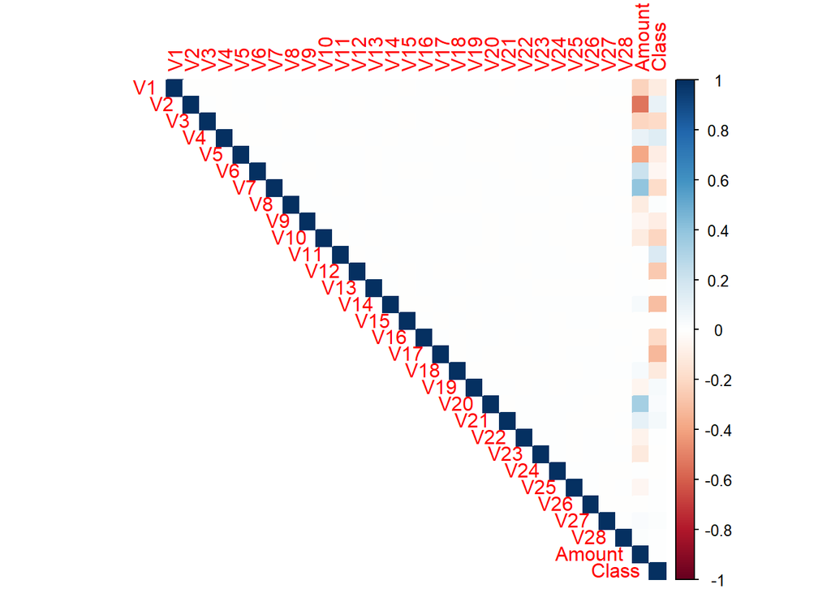

Looking at the features in a paired manner, we can see that the principle components capture the variance structure of the data set as expected (V1 captures the projection of greatest variance, V2 after that, and so on). There seem to be many variables with potential value for identifying fraudulent charges.

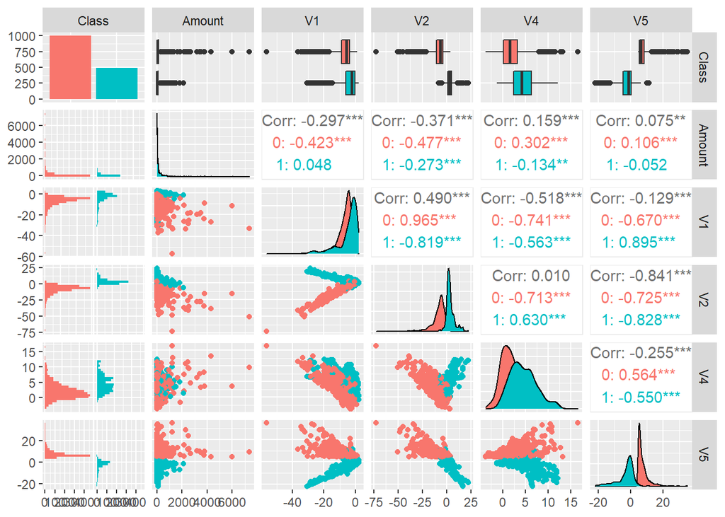

# Data Splitting

Training data.

| Class | n | prop |
| --- | --- | --- |
| 1 | 375 | 0.0017556 |
| 0 | 213230 | 0.9982444 |

Testing data.

| Class | n | prop |
| --- | --- | --- |
| 1 | 117 | 0.0016432 |
| 0 | 71085 | 0.9983568 |

The above two tables show that while our training and testing data sets contain independent instances, the proportion of fraudulent/non-fraudulent charges has been balanced between the two to ensure a fair assessment of performance.

# Modeling

To get a baseline measure of classification we train a logistic regression model on the imbalanced data set.

## Imbalanced Training

| Data Set | Accuracy | Sensitivity | Specificity | Precision | Recall | F1 Score |
| --- | --- | --- | --- | --- | --- | --- |
| Train | 0.9991901 | 0.6320000 | 0.9998359 | 0.8713235 | 0.6320000 | 0.7326121 |
| Test | 0.9992275 | 0.6324786 | 0.9998312 | 0.8604651 | 0.6324786 | 0.7290640 |

Training performed on the imbalanced data set.

By `accuracy` the model seems to perform quite well, but this is misleading given the strong class imbalance. Also included in the table are two groups of metrics that provide class-specific measures of performance.

- Sensitivity and Specificity
- Precision, Recall, and F1-Score

`Sensitivity` (also called `recall`) measures the proportion of positive cases correctly classified. Conversely, `specificity` measures the proportion of negative cases correctly classified. Given the context of this classification task, it is reasonable to aim to maximize sensitivity to ensure that all fraudulent charges are identified (even at the expense of incorrectly classifying some benign transactions as fraudulent).

$$Sensitivty = \frac{True\ Positives}{True\ Positives + False\ Negatives}$$

$$Specificity = \frac{True\ Negatives}{False\ Positives + True\ Negatives}$$

From a slightly different angle, `precision` measures the proportion of positively-classified instances that are truly positive.

$$Precision = \frac{True\ Positives}{True\ Positives + False\ Positives}$$

$$Recall = \frac{True\ Positives}{True\ Positives + False\ Negatives}$$

`Precision` and `recall` can be combined into a single measure that balances both positive and negative class performance.

$$F1 = \frac{2 \cdot Precision \cdot Recall}{Precision + Recall}$$

Unlike the tabular metrics discussed, an ROC curve provides a rank-based view of the ability of a classifier to separate classes.

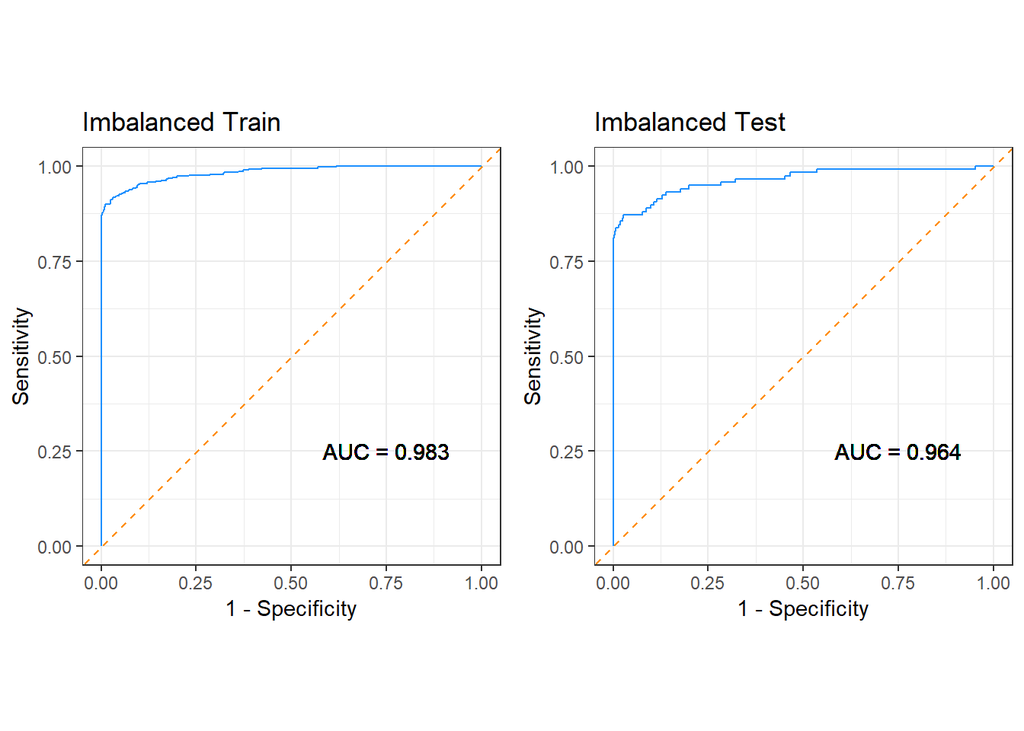

Looking at the confusion matrices, we see that a sizable number of fraudulent classes are being missed in both the training (n = 138) and testing (n = 43) data sets. For practical use, we need to substantially lower this number.

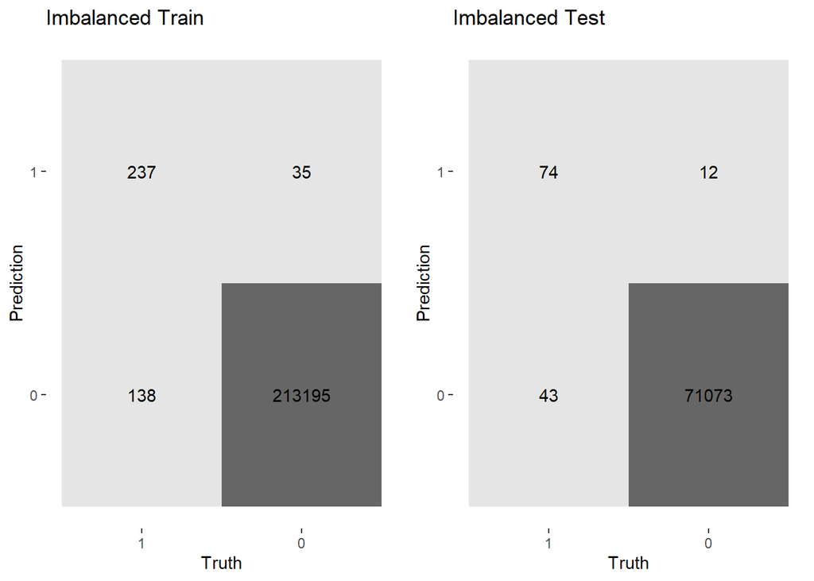

## Up-sampled Training

With baseline performance set, let’s use some sampling techniques to push the boundaries of classification and increase the number of fraudulent cases correctly classified.

Upsampling duplicates minority class instances to increase the number of examples and even-out the imbalance. This substantially increases the size of the training data set and is best applied to fast-training models (such as the linear models used here).

| Data Set | Accuracy | sensitivity | Specificity | Precision | Recall | F1 Score |
| --- | --- | --- | --- | --- | --- | --- |
| Train | 0.9791952 | 0.9280000 | 0.9792853 | 0.07303253 | 0.9280000 | 0.1354086 |
| Test | 0.9788068 | 0.8803419 | 0.9789688 | 0.06445557 | 0.8803419 | 0.1201166 |

Training performed on the data set upsampled on the minority class.

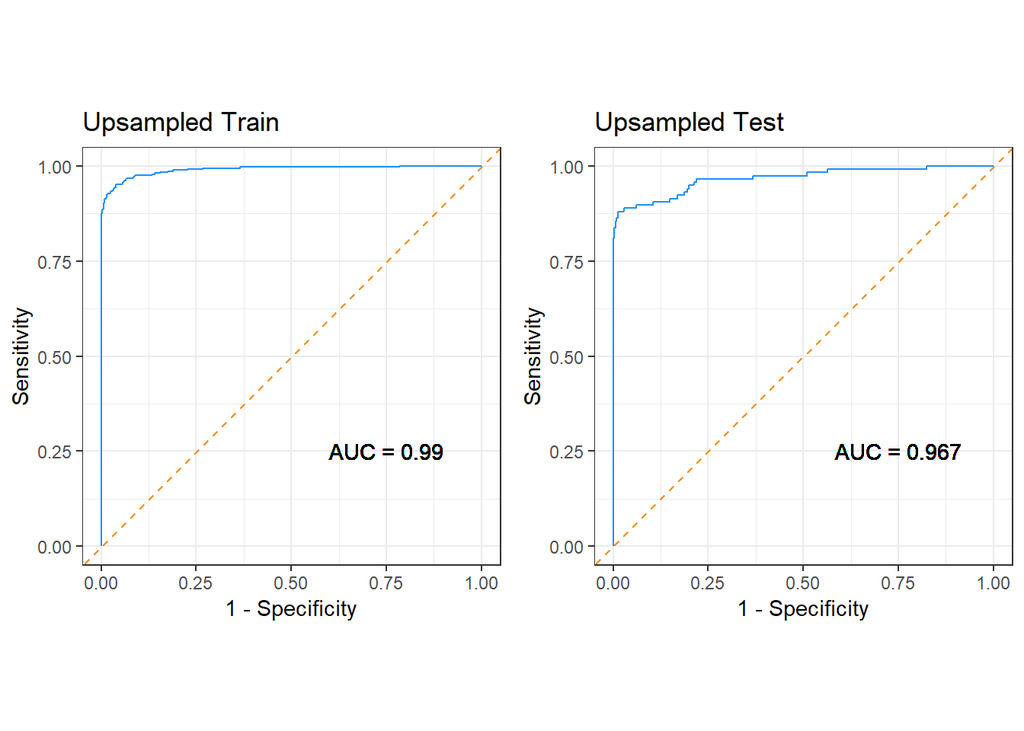

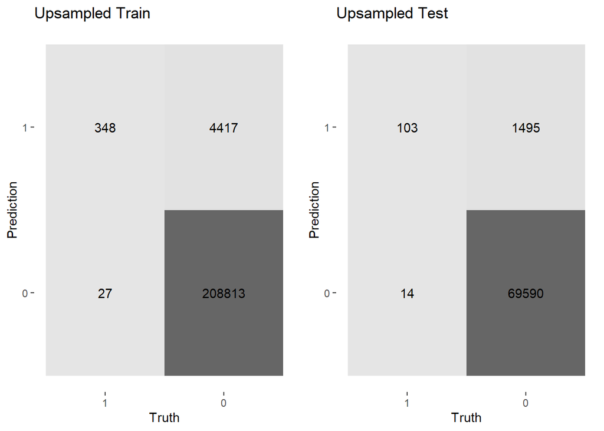

Reviewing the metrics above, we can see that up sampling has greatly improved our sensitivity to fraudulent transactions. However, this has come at the expense of increasing our false positive rate.

## Down-sampled Training

To combat the increasing number of false positives, we will train a model on a down sampled view of the data. With down sampling, examples of the majority class are discarded at random to better-balance the two classes. While this substantially reduces the size of the training data set, it can help shift focus to the minority class without over-emphasizing the limited variety of positive cases that could hurt the generalizability of the model.

| Data Set | Accuracy | sensitivity | Specificity | Precision | Recall | F1 Score |
| --- | --- | --- | --- | --- | --- | --- |
| Train | 0.9686711 | 0.9360000 | 0.9687286 | 0.05000712 | 0.9360000 | 0.09494184 |
| Test | 0.9673886 | 0.8974359 | 0.9675037 | 0.04347826 | 0.8974359 | 0.08293839 |

Training performed on a data set downsampled on the majority class.

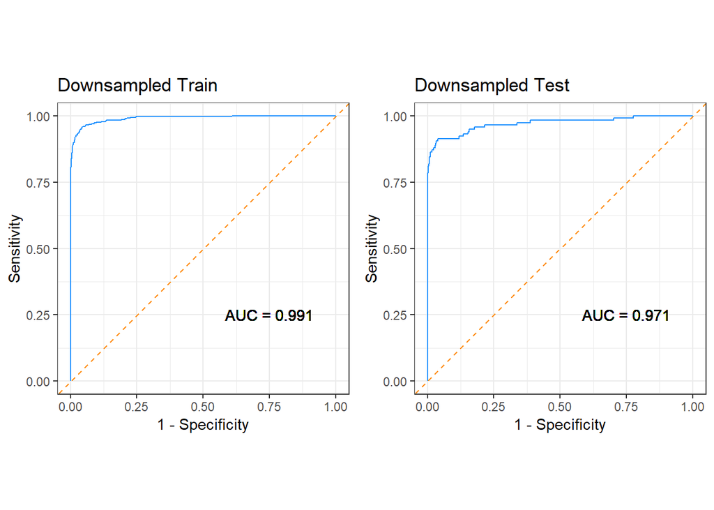

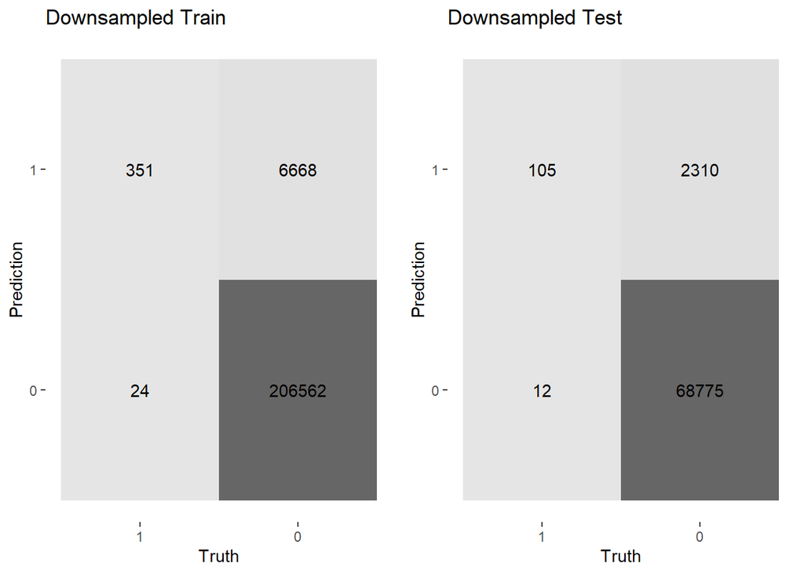

While down sampling helped reduced the number of mis-classified fraudulent transactions, the number of false positives substantially increased compared to the model trained on an up sampled data set. In this scenario, the up sampled model provides comparable fraud detection with a much lower false positive rate. The panel images below provide a quick comparison of all three approaches. While the ROC curves show all three models having similar ability to differentiate between classes at large, the confusion matrices highlight the benefits of the sampling techniques to improve detection of the minority class.

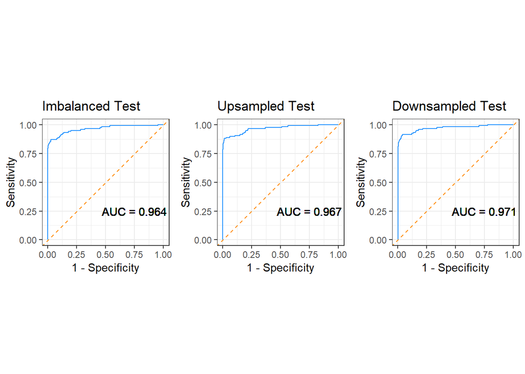

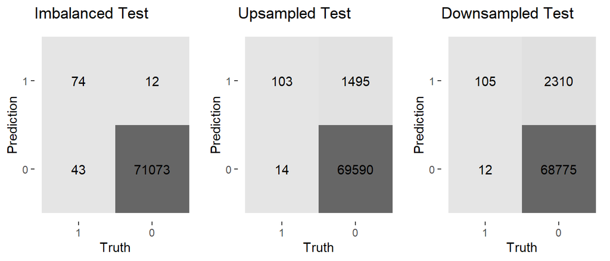